# Statistical inference, part II

Rank-based tests, multiple testing, interval estimates and ANOVA

Eva Freyhult

NBIS, SciLifeLab

September 9, 2026

# Rank-based tests

Rank-based tests are useful alternatives when the assumptions of parametric tests are doubtful. They are often used when the data are skewed, contain outliers, are measured on an ordinal scale, or when the sample size is small and normality is uncertain.

Instead of using the observed values directly, rank-based tests are based on the ordering of the observations.

- one-sample or paired t-test $\rightarrow$ Wilcoxon signed-rank test
- two-sample t-test $\rightarrow$ Mann–Whitney / Wilcoxon rank-sum test
- one-way ANOVA $\rightarrow$ Kruskal–Wallis test

## Two independent samples

For comparing two independent groups when a two-sample t-test is not appropriate, a rank-based alternative is the **Mann–Whitney test**, also known as the **Wilcoxon rank-sum test**.

The hypotheses may be written as

$$H_0: \text{the two groups come from the same distribution}$$
$$H_1: \text{the two groups differ in location}$$

In practice, the test is often interpreted as a test of whether one group tends to have larger values than the other.

The test is performed by pooling all observations from both groups, ranking them from smallest to largest, and comparing the sums of ranks between the groups.

In R:

```r
x1 <- c(18, 21, 19, 25, 27, 23, 22)
x2 <- c(14, 15, 17, 16, 19, 18, 15)
wilcox.test(x1, x2)
```

```
    Wilcoxon rank sum exact test

data:  x1 and x2
W = 47, p-value = 0.003
alternative hypothesis: true location shift is not equal to 0
```

## Paired samples

For paired data, a rank-based alternative to the paired t-test is the **Wilcoxon signed-rank test**.

As for the paired t-test, the analysis is based on the within-pair differences. However, instead of using the observed differences directly, the Wilcoxon signed-rank test uses the ranks of the absolute differences together with their signs.

The hypotheses are commonly expressed as

$$H_0: \text{the distribution of within-pair differences is centered at 0}$$
$$H_1: \text{the distribution of within-pair differences is not centered at 0}$$

In R:

```r
before <- c(132, 128, 136, 141, 130, 125, 138, 129)
after  <- c(127, 125, 130, 136, 128, 121, 134, 126)
wilcox.test(after, before, paired=TRUE)
```

```
    Wilcoxon signed rank exact test

data:  after and before
V = 0, p-value = 0.008
alternative hypothesis: true location shift is not equal to 0
```

## Choosing test

| Study design | Parametric test | Rank-based alternative |
| --- | --- | --- |
| One sample | One-sample t-test | Wilcoxon signed-rank test |
| Two independent groups | Two-sample t-test | Mann–Whitney / Wilcoxon rank-sum test |
| Paired samples | Paired t-test | Wilcoxon signed-rank test |
| More than two independent groups | One-way ANOVA | Kruskal–Wallis test |

The choice of test depends on the study design and whether the assumptions of the parametric test are reasonable.

# Multiple testing

## Error types

Table 1: A hypothesis test either rejects $H_0$ or fails to reject $H_0$. The decision may be correct or incorrect depending on whether $H_0$ is true or false. TN = true negative, TP = true positive, FN = false negative, FP = false positive.

| Decision | H₀ is true | H₀ is false |
| --- | --- | --- |
| Fail to reject H₀ | TN | Type II error, miss, FN |
| Reject H₀ | Type I error, false alarm, FP | TP |

Remember that the probability of type I and II errors are denoted $\alpha$ and $\beta$, respectively;

$$\alpha = P(\textrm{type I error}) = P(\textrm{false alarm}) = P(\textrm{Reject }H_0 \mid H_0 \text{ is true})$$
$$\beta = P(\textrm{type II error}) = P(\textrm{miss}) = P(\textrm{Fail to reject }H_0 \mid H_1 \text{ is true})$$

and the statistical power

$$\textrm{power} = 1 - \beta = P(\textrm{Reject }H_0 \mid H_1\textrm{ is true}).$$

## Multiple testing

If a single test is performed, we know that

- P(One type I error) = $\alpha$
- P(No type I error) = $1 - \alpha$

If $m$ independent tests are performed, the risk of at least one false alarm increases;

- P(No type I errors in $m$ tests) = $(1 - \alpha)^m$
- P(At least one type I error in $m$ tests) = $1 - (1 - \alpha)^m$

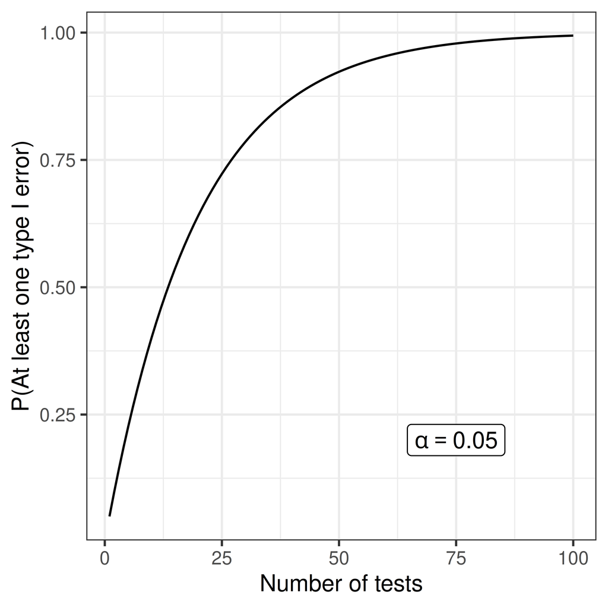

## Multiple testing correction

Two common principles for dealing with multiple testing are control of family-wise error rate or false discovery rate.

- FWER: family-wise error rate, control the probability of one or more false positives, $P(N_{FP}>0)$, e.g. Bonferroni, Holm
- FDR: false discovery rate, control the expected proportion of false positives among the rejected hypotheses, $E[N_{FP}/(N_{FP}+N_{TP})]$, e.g. Benjamini-Hochberg, Storey

## Bonferroni correction

To achieve a family-wise error rate of $FWER \leq \gamma$ when performing $m$ tests, declare significance and reject the null hypothesis for any test with $p \leq \gamma/m$.

A disadvantage of the Bonferroni correction is that it can be overly conservative, especially when many tests are performed.

## Benjamini-Hochberg FDR procedure

| Decision | H₀ is true | H₀ is false |
| --- | --- | --- |
| Fail to reject H₀ | TN | FN |
| Reject H₀ | FP | TP |

The false discovery rate is the expected proportion of false positives among ‘hits’, i.e. $\frac{FP}{TP+FP}$.

The Benjamini-Hochberg procedure controls the FDR level, $\gamma$, under the assumption of independence (and also under certain forms of positive dependence) when performing $m$ tests, as follows:

1. Sort the p-values $p_1 \leq p_2 \leq \dots \leq p_m$.
2. Find the maximum $j$ such that $p_j \leq \gamma \frac{j}{m}$.
3. Declare significance for all tests $1, 2, \dots, j$.

## Adjusted p-values

Sometimes an adjusted significance threshold is not reported, but instead adjusted p-values are reported.

- Using Bonferroni’s method the adjusted p-values are:

  $\tilde p_i = \min(m p_i, 1)$
- Benjamini-Hochberg adjusted p-values are often referred to as q-values:

  $q_i = \min(\frac{m}{i} p_i, 1)$

In practice, adjusted p-values are usually computed using software such as the R function `p.adjust`.

## Example, 10000 independent tests (e.g. genes)

| p-value | adj p (Bonferroni) | q-value (B-H) |
| --- | --- | --- |
| 1.7e-08 | 0.0002 | 0.0002 |
| 5.8e-08 | 0.0006 | 0.0003 |
| 3.4e-07 | 0.0034 | 0.0011 |
| 9.1e-07 | 0.0091 | 0.0020 |
| 1e-06 | 0.0100 | 0.0020 |
| 2.4e-06 | 0.0240 | 0.0040 |
| 2.3e-05 | 0.2300 | 0.0329 |
| 3.6e-05 | 0.3600 | 0.0450 |
| 0.00022 | 1.0000 | 0.2300 |
| 0.00023 | 1.0000 | 0.2300 |
| 0.00073 | 1.0000 | 0.6636 |
| 0.0032 | 1.0000 | 1.0000 |
| 0.0045 | 1.0000 | 1.0000 |
| 0.0087 | 1.0000 | 1.0000 |
| 0.0089 | 1.0000 | 1.0000 |
| 0.012 | 1.0000 | 1.0000 |
| 0.014 | 1.0000 | 1.0000 |
| 0.045 | 1.0000 | 1.0000 |
| 0.08 | 1.0000 | 1.0000 |
| 0.23 | 1.0000 | 1.0000 |

# Point and interval estimates

## Point estimate

Unknown population parameters can be estimated from random samples drawn from the population of interest. A value computed from the sample can be used as a **point estimate**, that is, a single-number estimate of the population parameter.

An **estimator** is a random variable computed from the sample, whereas an **estimate** is its observed value for a particular sample.

## Bias and precision

The sample proportion and sample mean are unbiased estimators of the corresponding population parameters. Although these estimators are unbiased, they still vary from sample to sample. In general, the variability decreases as the sample size increases.

An estimator is **unbiased** if its expected value equals the population parameter it is intended to estimate.

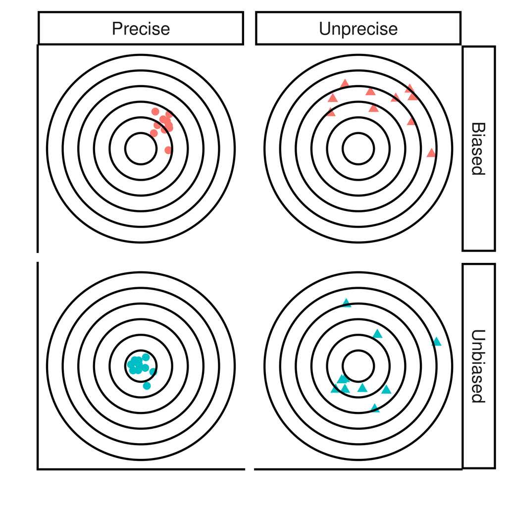

Figure 1: Bias and precision.

## Interval estimates

A point estimate gives a single best guess of the population parameter, whereas an interval estimate gives a range of plausible values and reflects the uncertainty due to sampling.

To show this uncertainty, an **interval estimate** for a population parameter can be computed instead of reporting only a point estimate.

## Confidence interval

A confidence interval is a type of interval estimate associated with a confidence level.

> A confidence interval for $\theta$ with confidence level $1 - \alpha$ is a method for constructing intervals such that, in repeated sampling, a proportion $1-\alpha$ of the intervals will contain the true population parameter $\theta$.

## Sampling distribution of mean

$$\bar X \sim N(\mu, \frac{\sigma}{\sqrt{n}})$$

[figure not shown]

## Sampling distribution of mean

$$\bar X \sim N(\mu, \frac{\sigma}{\sqrt{n}})$$

[figure not shown]

## Sampling distribution of mean

$$\bar X \sim N(\mu, \frac{\sigma}{\sqrt{n}})$$

[figure not shown]

## Sampling distribution of mean

$$\bar X \sim N(\mu, \frac{\sigma}{\sqrt{n}})$$

[figure not shown]

## Confidence interval

Based on a random sample compute the sample mean $m$.

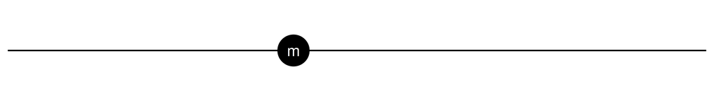

Use what is known about the sampling distribution and compute a confidence interval around $m$.

[figure not shown]

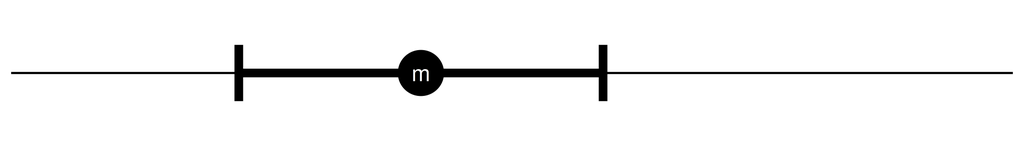

## Confidence interval of mean

If $\sigma$ is known

$$Z = \frac{\bar X - \mu}{SEM} = \frac{\bar X - \mu}{\frac{\sigma}{\sqrt{n}}} \sim N(0, 1)$$

## Standard normal distribution

$$P\left(-z_{\alpha/2} < Z <z_{\alpha/2}\right) = 1-\alpha$$

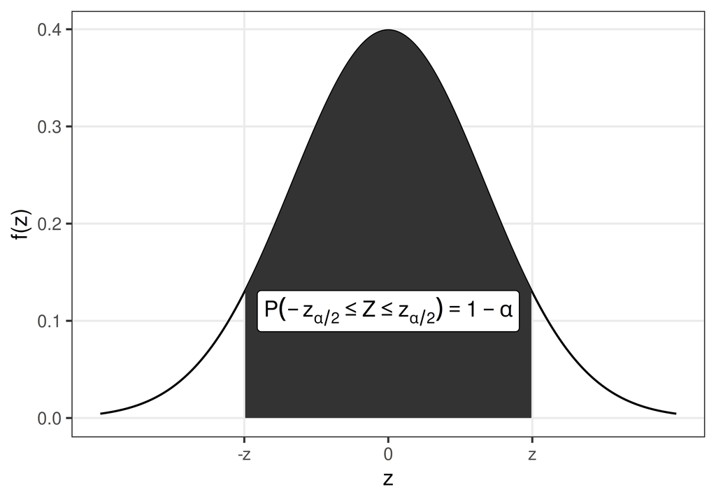

## Standard normal distribution

$$P\left(-z_{\alpha/2} < Z <z_{\alpha/2}\right) = 1-\alpha$$

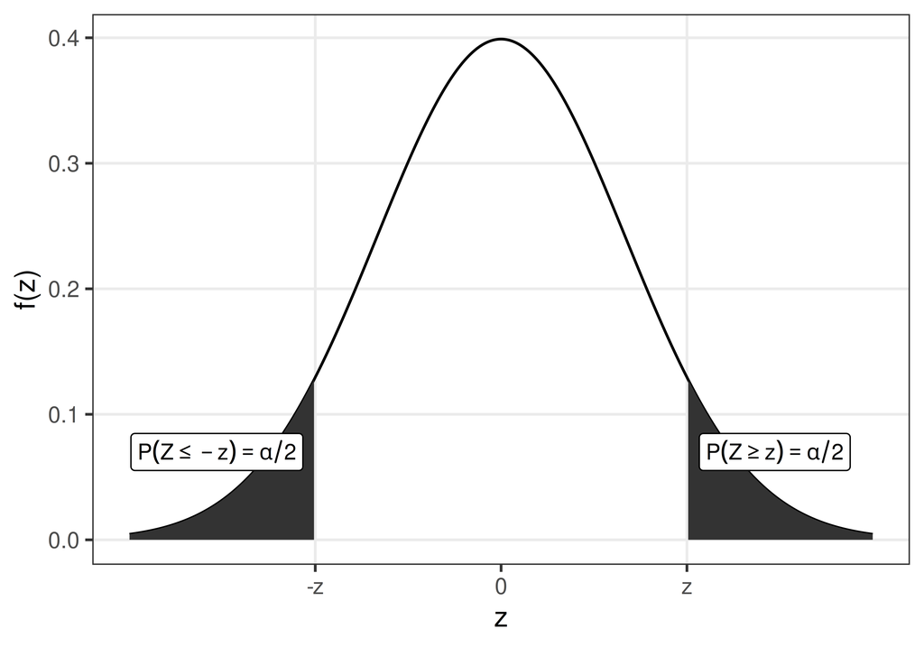

$z_{\alpha/2}$ is the value such that $P(Z \geq z_{\alpha/2}) = \frac{\alpha}{2} \iff P(Z \leq z_{\alpha/2}) = 1 - \frac{\alpha}{2}$.

For a 95% confidence interval, $\alpha = 0.05$, and $z_{\alpha/2} = 1.96$. For 90% or 99% confidence $z_{0.05} = 1.64$ and $z_{0.005}=2.58$.

## Confidence interval of mean

If $\sigma$ is known

$$Z = \frac{\bar X - \mu}{SEM} = \frac{\bar X - \mu}{\frac{\sigma}{\sqrt{n}}} \sim N(0, 1)$$
From the standard normal distribution we know;

$$P(-z_{\alpha/2}<Z<z_{\alpha/2}) = 1-\alpha$$

$$P(-z_{\alpha/2}<\frac{\bar X-\mu}{SEM}<z_{\alpha/2}) = 1-\alpha$$

$$P(\mu-z_{\alpha/2}SEM<\bar X<\mu+z_{\alpha/2}SEM) = 1-\alpha$$

$$P(\bar X-z_{\alpha/2}SEM<\mu<\bar X+z_{\alpha/2}SEM) = 1-\alpha$$

Replace with an observed sample mean, $\bar x$.

$$P(\bar x_{obs}-z_{\alpha/2}SEM<\mu<\bar x_{obs}+z_{\alpha/2}SEM) = 1-\alpha$$

## Confidence interval of mean

If $\sigma$ is known

$$[\bar x_{obs} - z_{\alpha/2}SEM, \bar x_{obs} + z_{\alpha/2}SEM]$$

or

$$\mu = \bar x_{obs} \pm z_{\alpha/2}SEM$$

where $SEM = \frac{\sigma}{\sqrt{n}}$.

## Confidence interval of mean

If $\sigma$ is unknown and the observations are approximately normally distributed, use the t distribution instead.

$$T = \frac{\bar X - \mu}{\frac{s}{\sqrt{n}}} \sim t(n-1)$$

It follows that the confidence interval is

$$[\bar x_{obs} - t\frac{s}{\sqrt{n}}, \bar x_{obs} + t\frac{s}{\sqrt{n}}]$$

or

$$\mu = \bar x_{obs} \pm t\frac{s}{\sqrt{n}}$$

## Confidence interval of mean

For a 95% confidence interval and $n=5$, the critical value is 2.7764.

The $t$ values for different values of $\alpha$ and degrees of freedom are tabulated and can be computed in R using the function `qt`.

```r
n=5
alpha = 0.05
qt(1-alpha/2, df=n-1)
```

```
[1] 2.776
```

## Example

You study the BMI of male diabetic patients. In a sample of size 6 you observe; $27, 25, 31, 29, 30, 22$. Assume that the BMI is normally distributed and calculate a 95% confidence interval for the mean BMI in male diabetic patients.

The sample mean is $\bar x = 27.3$ and the sample standard deviation is $s = 3.39$. The degrees of freedom is $n-1 = 5$ and the $t$ value for a 95% confidence interval is 2.5706.

The confidence interval is $\bar x \pm t \frac{s}{\sqrt{n}} = 27.3 \pm 2.57 \frac{3.39}{\sqrt{6}} = 27.3 \pm 3.5$.

```r
x <- c(27, 25, 31, 29, 30, 22)
(m <- mean(x))
```

```
[1] 27.33
```

```r
(s <- sd(x))
```

```
[1] 3.386
```

```r
(q <- qt(0.975, df=5))
```

```
[1] 2.571
```

```r
(SEM <- s/sqrt(6))
```

```
[1] 1.382
```

```r
(CI <- m + c(-1,1)*q*SEM)
```

```
[1] 23.78 30.89
```

## Bootstrap interval

If the sampling distribution is unknown, a bootstrap interval can be computed instead.

Bootstrapping is performed by resampling with replacement from the available random sample. The resulting bootstrap distribution can then be used to calculate, for example, a 95% bootstrap interval.

```r
x <- c(27, 25, 31, 29, 30, 22)
mboot <- replicate(1000, mean(sample(x, replace=TRUE)))
ciboot <- quantile(mboot, c(0.025, 0.975))
```

[figure not shown]

# Analysis of variance (ANOVA)

With one numeric response variable of interest and one categorical variable with $k$ groups, we can use **one-way ANOVA** to test if the group means are equal.

Hypotheses:

$$H_0: \mu_1=\mu_2=\cdots=\mu_k$$
$$H_1: \text{not all group means are equal}$$

## ANOVA compares between-group and within-group variation

$$F = \frac{\text{variation between groups}}{\text{variation within groups}}$$

[figure not shown]

(a) Large within-group variation compared to between-group variation.

[figure not shown]

(b) Small within-group variation compared to between-group variation.

Figure 2: ANOVA compares the separation between group means to the variation within groups.

## Sum of squares

The sum of squares (SS) is a measure of variation, the cumulative squared deviation of each observation from the mean.

In ANOVA, we partition the total variation ($SS_{total}$) in the response variable into two components: the variation between groups ($SS_{between}$) and the variation within groups ($SS_{within}$).

$$SS_{total} = SS_{between} + SS_{within}$$

$$SS_{between} = \sum_{i=1}^k n_i (\bar Y_i - \bar Y)^2$$
$$SS_{within} = \sum_{i=1}^k \sum_{j=1}^{n_i} (Y_{ij} - \bar Y_i)^2$$

## Mean squares and F statistic

The mean squares are computed by dividing the sum of squares by their respective degrees of freedom:

$$MS_{between} = \frac{SS_{between}}{k - 1}$$
$$MS_{within} = \frac{SS_{within}}{N - k}$$

and the ANOVA test statistic, the F statistic, is computed as

$$F = \frac{MS_{between}}{MS_{within}}$$

Under $H_0$, the F statistic is F distributed with $k - 1$ and $N - k$ degrees of freedom.

## Assumptions

The one-way ANOVA has three main assumptions:

- independent observations
- approximately normally distributed observations within groups
- equal variances across groups

If the assumptions are doubtful, a rank-based alternative is the **Kruskal–Wallis test**.

## Post hoc test

The ANOVA test is an omnibus test. A significant ANOVA result indicates that at least one group mean is different from the others, but it does not specify which groups differ.

To identify the specific group differences, we can perform post hoc pairwise comparisons between the groups. A common post hoc test is **Tukey’s Honest Significant Difference (HSD)** test.

In R, one-way ANOVA can be fitted using `aov`, and post hoc comparisons can be performed using `TukeyHSD`:

```r
set.seed(123)
df <- data.frame(
  group = factor(rep(c("A", "B", "C"), each = 10)),
  response = c(rnorm(10, mean = 5, sd = 1), rnorm(10, mean = 6, sd = 1), rnorm(10, mean = 7, sd = 1))
)
fit <- aov(response ~ group, data = df)
summary(fit)
```

```
            Df Sum Sq Mean Sq F value Pr(>F)
group        2   12.2    6.12    6.44 0.0052 **
Residuals   27   25.7    0.95
---
Signif. codes:  0 '***' 0.001 '**' 0.01 '*' 0.05 '.' 0.1 ' ' 1
```

```r
TukeyHSD(fit)
```

```
  Tukey multiple comparisons of means
    95% family-wise confidence level

Fit: aov(formula = response ~ group, data = df)

$group
      diff      lwr   upr  p adj
B-A 1.1340  0.05254 2.215 0.0385
C-A 1.5008  0.41936 2.582 0.0052
C-B 0.3668 -0.71464 1.448 0.6812
```

## Kruskal-Wallis test

If the assumptions of one-way ANOVA are not fulfilled, a rank-based alternative is the **Kruskal–Wallis test**. This test compares the groups using the ranks of the observations rather than the raw values.

A significant Kruskal–Wallis test indicates that at least one group differs from the others, but like ANOVA, it does not show which groups differ.

In R, the Kruskal–Wallis test can be performed using the function `kruskal.test`.

```r
kruskal.test(response ~ group, data = df)
```

```
    Kruskal-Wallis rank sum test

data:  response by group
Kruskal-Wallis chi-squared = 8.2, df = 2, p-value = 0.02
```